# Graphical methods 1

Oscar Rodriguez de Rivera

Within this worksheet we are going to look at producing some basic graphs in R.

### Line graphs

Line charts are useful for displaying time-series data. We will start by producing a very simple graph using the values in a vector called birds. This data set corresponds to the count of the number of birds observed feeding between 8am and 7pm at hourly intervals. We define the birds vector with 12 values:

```r
birds <- c(3, 7, 5, 8, 9, 4, 6, 5, 7, 8, 2, 8)
```

We now produce a basic graph:

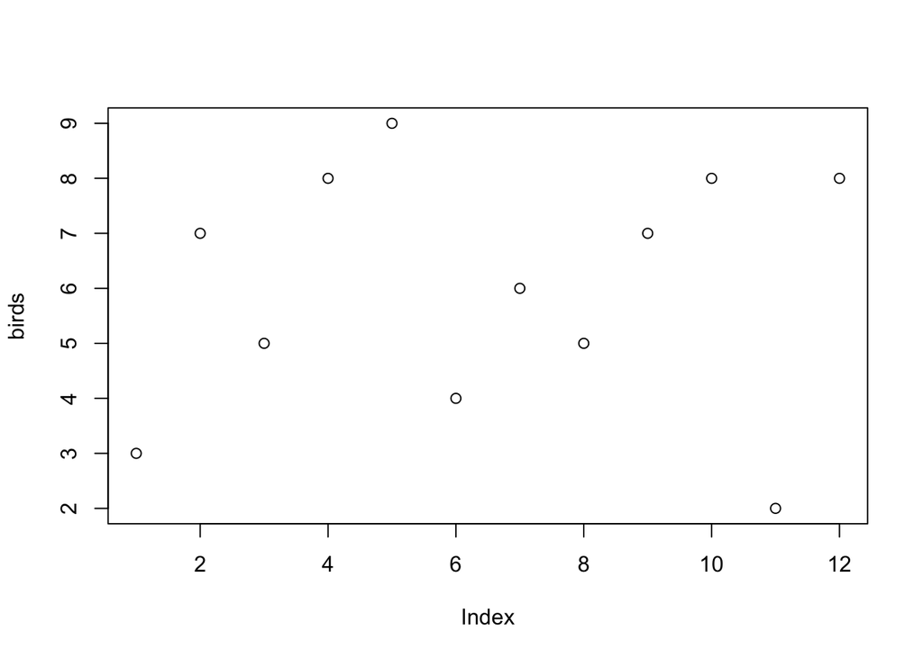

```r
plot(birds)
```

This graph is not very informative because it has used all of the default function settings. Type `?plot` to find out more about the options within this function. Suppose we want the x-axis of the graph to denote the time of day the observations were observed. Let us define a new vector:

```r
time.of.day <- 8:19
```

Then we can plot time.of.day against birds:

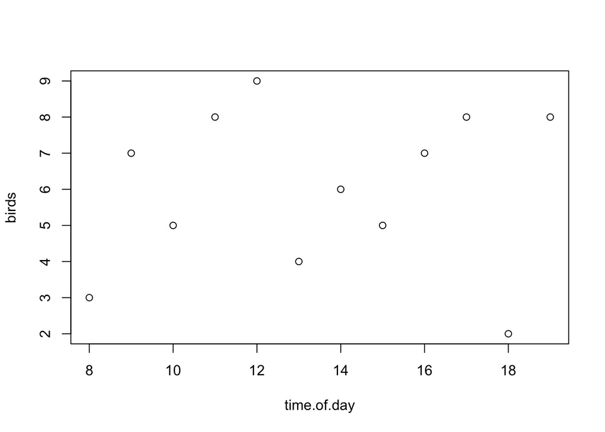

```r
plot(time.of.day,birds)
```

We can add a title and a line to connect the points, and some colour as follows:

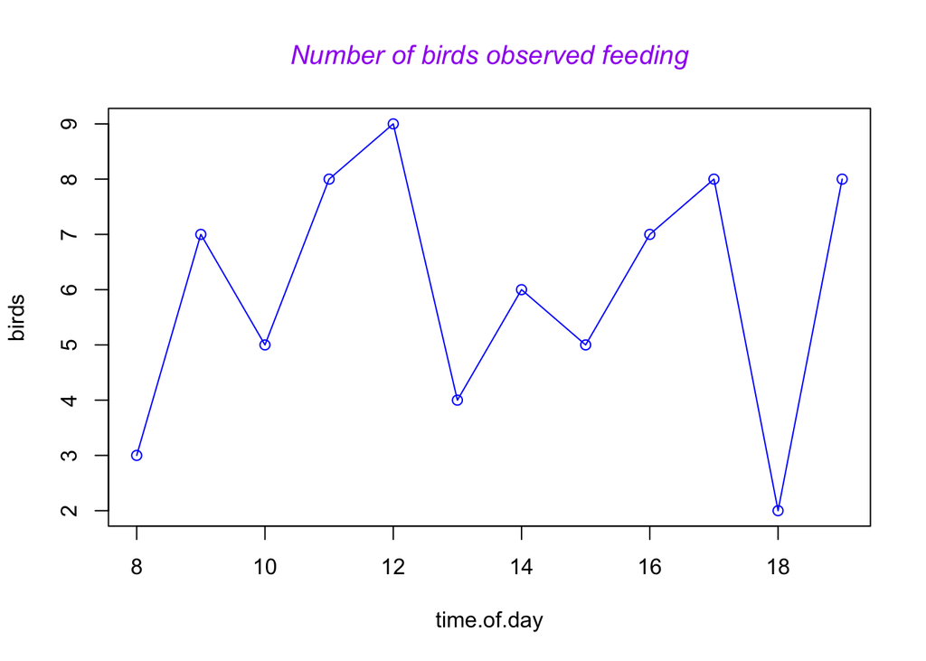

```r
plot(time.of.day,birds, type="o", col="blue")
title(main="Number of birds observed feeding", col.main="purple", font.main=3)
```

If we want to change the x and y-axis labels we have to set these within the plot function:

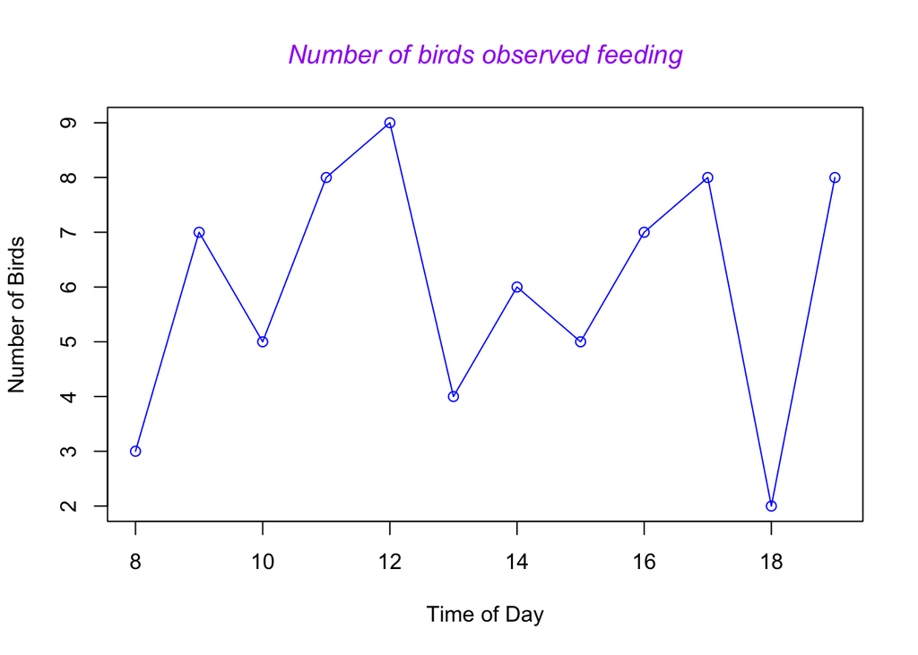

```r
plot(time.of.day,birds, type="o", col="blue", xlab="Time of Day", ylab="Number of Birds")
title(main="Number of birds observed feeding", col.main="purple", font.main=3)
```

Now suppose we also have data for cats which we want to show on the same graph. Let us load the cat data into R:

```r
cats <- c(9, 10, 14, 5, 10, 18, 17, 16, 9, 8, 6, 12)
```

Plot the bird line and use the lines function to add the cat line:

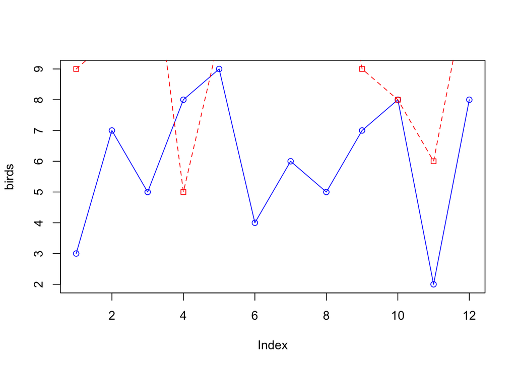

```r
plot(birds, type="o", col="blue")
lines(cats, type="o",pch=22, lty=2, col="red")
```

You will see that the cat line is not fully displayed on this plot as the y-axis does not go high enough. This is an annoyance of base R graphics. Adding a second line to a graph you must consider the initial plot to be fixed as an image file and then the 2nd line is added to that image. So you have to pre-set the axes ranges when you plot the initial line:

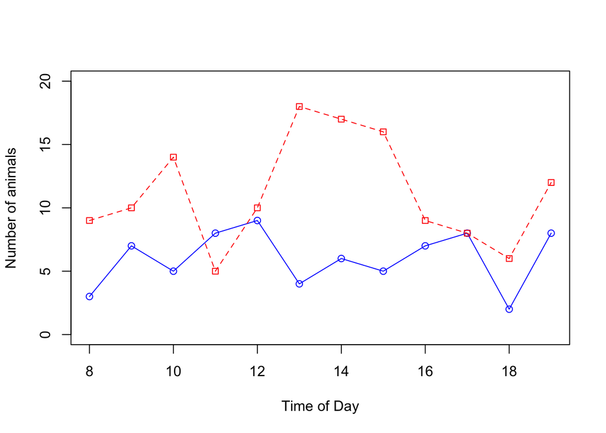

```r
plot(time.of.day,birds, type="o", col="blue",ylim=c(0,20),
 ylab="Number of animals",xlab="Time of Day")
lines(time.of.day,cats, type="o",pch=22, lty=2, col="red")
```

Next we might want to add a legend to let people know what the blue and red lines represent:

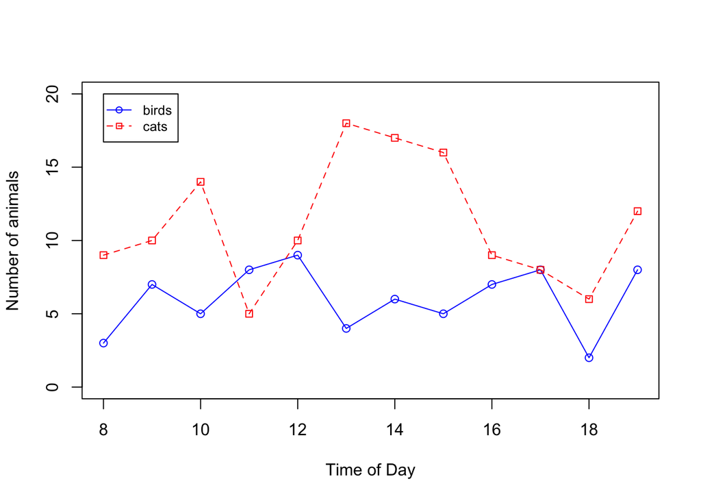

```r
plot(time.of.day,birds, type="o", col="blue",ylim=c(0,20),
 ylab="Number of animals",xlab="Time of Day")
lines(time.of.day,cats, type="o",pch=22, lty=2, col="red")
legend(8, 20, c("birds","cats"), cex=0.8, col=c("blue","red"), pch=21:22, lty=1:2)
```

The 8 and 20 in this command represent that we want the top left-hand corner of the legend box to sit at the point x = 8 and y = 20 of the graph.

- **Exercise**

Every year researchers count the number of ibex in Gran Paradiso National Park in Italy. The numbers of males and females counted at the park between 1956 and 2016 are provided in `ibex_counts.txt` which can be found on moodle. Read the data into R and construct a line plot showing the data for both males and females.

*Note: you might use the function max to find out what the limits of the y-axis need to be.*

**Solution**

### Pie charts

The file BirdFluCases.txt contains the annual number of confirmed cases of human Avian Influenza A (H5N1) for several countries reported to the World Health Organization.

Read the data into R.

We have annual data from the years 2003-2008. The first variable contains the years. There are various things we can learn from this data set. An interesting question is whether the number of bird flu cases has increased over time. We can address this question for individual countries or for the total number of cases. The latter is calculated by

```r
BirdFluCases <- read.delim("~/Dropbox/Rcourse/day1/BirdFluCases.txt")
Cases <- rowSums(BirdFluCases[,2:16])
names(Cases) <- BirdFluCases[,1]
Cases
```

```
## 2003 2004 2005 2006 2007 2008
##    4   46   98  115   88   34
```

The `name` command assigns a label to each data point which will then be used to label the segments on the pie chart you produce. The label we have assigned here is the year the cases correspond to.

Now let us plot some pie charts of this case data. We want to plot 4 graphs on the same display so we use the following command to split the window into 4. Note when you run this command you will not see any change until you plot your graphs.

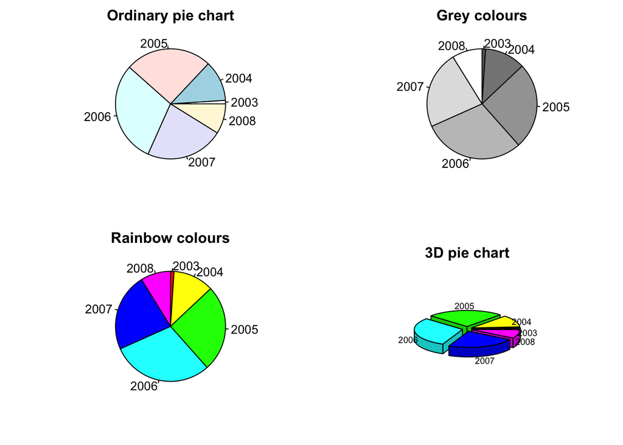

```r
par(mfrow = c(2,2), mar = c(3, 3, 2, 1))

#We are going to plot 4 different pie charts:
pie(Cases, main="Ordinary pie chart")
pie(Cases, col=gray(seq(0.4, 1.0, length = 6)), clockwise=TRUE, main="Grey colours")
pie(Cases, col=rainbow(6), clockwise=TRUE, main="Rainbow colours")

#For the last pie chart we are going to use an package called plotrix:

#install.packages("plotrix")
library(plotrix)
pie3D(Cases, labels=names(Cases),explode=0.1, main="3D pie chart", labelcex = 0.6)
```

You will notice that although the 3D pie chart is possible, if anything it is less clear in its presentation than the other three graphs. Don’t overcomplicate your plots!

- **Exercise**

For the ibex population in 1956 there were 681 males, 680 females, 233 yearlings and 352 kids. In 2016 there were 895 males, 1122 females, 206 yearlings and 478 kids. Plot two pie charts side by side to show these data.

You will first need to input the data in the appropriate format:

```r
ibex_1956<-c(681,680,233,352)
ibex_2016<-c(895,1122,206,478)
names(ibex_1956)<-c("Males","Females","Yearlings","Kids")
names(ibex_2016)<-c("Males","Females","Yearlings","Kids")
```

**Solution**

### Bar charts

In the previous section an avian influenza data set was used to create pie charts showing the total number of cases per year. In addition to bird flu cases, the number of deaths is also available on moodle in file `BirdFluDeaths.txt`.

```r
BirdFluDeaths <- read.delim("~/Dropbox/Rcourse/day1/BirdFluDeaths.txt")
Deaths <- rowSums(BirdFluDeaths[,2:16])
names(Deaths) <- BirdFluDeaths[,1]
Deaths
```

```
## 2003 2004 2005 2006 2007 2008
##    4   32   43   79   59   26
```

The data are structured in the same manner as the bird flu cases. We can visualise the change in the number of cases over time, and then compare number of cases to deaths.

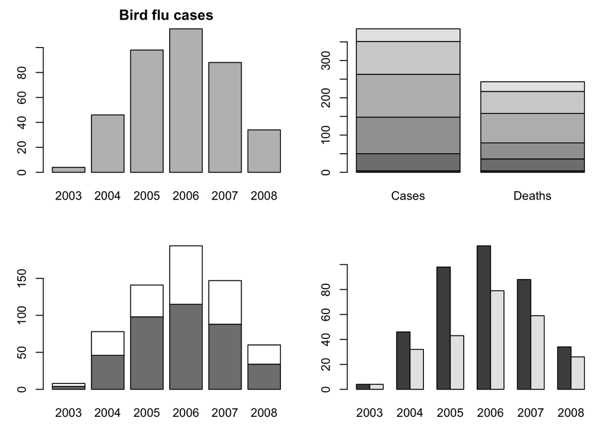

```r
par(mfrow = c(2,2), mar = c(3, 3, 2, 1))
barplot(Cases, main="Bird flu cases")
Counts <- cbind(Cases, Deaths)
barplot(Counts)
barplot(t(Counts), col=gray(c(0.5, 1)))
barplot(t(Counts), beside=TRUE)
```

The top left hand plot is a simple bar plot of the number of cases of bird flu over time. In the top right hand plot the bars represent data for each year. The graph gives little useable information. Also, years with very small numbers, e.g. 2003 are barely visible. In the bottom left hand plot the cases and deaths are stacked and such plots can be misleading. The clearest plot is the one in the bottom right hand plot which shows bars next to each other for each of the years. Note suppose we just want to plot the final graph and add a legend and axes labels we would use the following commands.

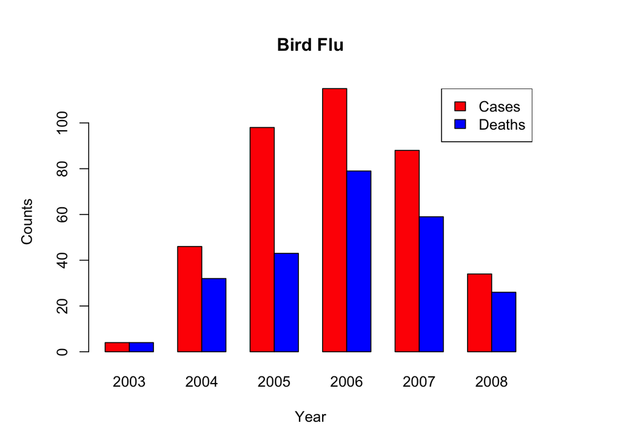

```r
par(mfrow = c(1,1),mar = c(5, 5, 5, 5))
barplot(t(Counts), beside=TRUE,col = c("red","blue"))
title(main="Bird Flu",xlab="Year",ylab="Counts")
legend("topright", legend = c("Cases", "Deaths"),fill = c("red", "blue"))
```

Note that we have had to increase the margin size using the mar command in the top line of code in order to be able to see the x and y labels on the axes.

- **Exercise**

The file `births_maternal_age.txt` contains the numbers of live births per age class of women in several years between 1947 and 2017. Plot some appropriate bar charts to compare the numbers of births by age group and by year. Note that the data file contains the variable names in the header row. You need to select the appropriate option when you import the data.

**Solution**